# SNP QC and sample Call rates

Shea Andrews

4/2/2018

## SNP QC

SNP level QC consists of removing markers that with excessive level missing genotypes and removal of markers with a low allele frequency. The presence of suboptimal makers can increases false positives and reduce the power to identify true associations correlated with disease risk. Standard thresholds for SNPs call rate and MAF are < 95% and < 1% respectivly.

Filtering SNPs on MAF and call rate can be done in PLINK by typing the following at the shell prompt:

```bash
plink_1.9 --bfile raw-GWA-data \
  --geno 0.05 --maf 0.01 \
  --make-bed --out filtered-GWA-data
```

Figure 1 shows the SNP call rate versus minor allele frequncy across all typed SNPs in the study. The dashed lines denote the MAF and call rate QC thresholds. 1338 SNPs will be removed due to low call rate and 232439 SNPs will be removed due to low minor allele frequency.

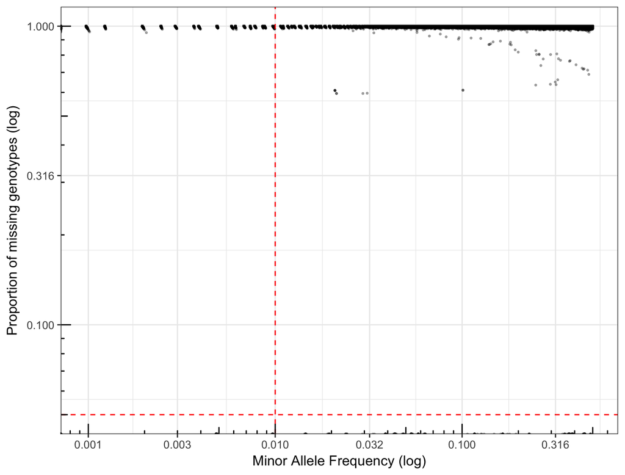

Fig. 1: Call rate by minor allele frequency

## Hardy Weinberg Equilibrium

Violations of Hardy Weinberg Equilibrium can indicate either the presence of population substructure, or the occurence of genotyping error. It is common practice to assume that violoations are indicative of genotyping error and remove SNPs in which the HWE test statistic has a corresponding p-value of less then 1x10-6.

Filtering SNPs on Hardy Weinberg Equilibrium for autosomes only can be done in PLINK by typing the following at the shell prompt:

```bash
plink_1.9 --bfile raw-GWA-data  \
  --autosome \
  -- hardy \
  --hwe 0.000001 \
  --make-bed --out filtered-GWA-data
```

## Sample Call Rate

A low genotyping call rate in a sample can be indicative of poor DNA sample quality and samples with a call rate < 0.95 are excluded from further analysis.

Filtering samples on call rate can be done in PLINK by typing the following at the shell prompt:

```bash
plink_1.9 --bfile raw-GWA-data  \
  --mind 0.05 \
  --make-bed --out filtered-GWA-data
```

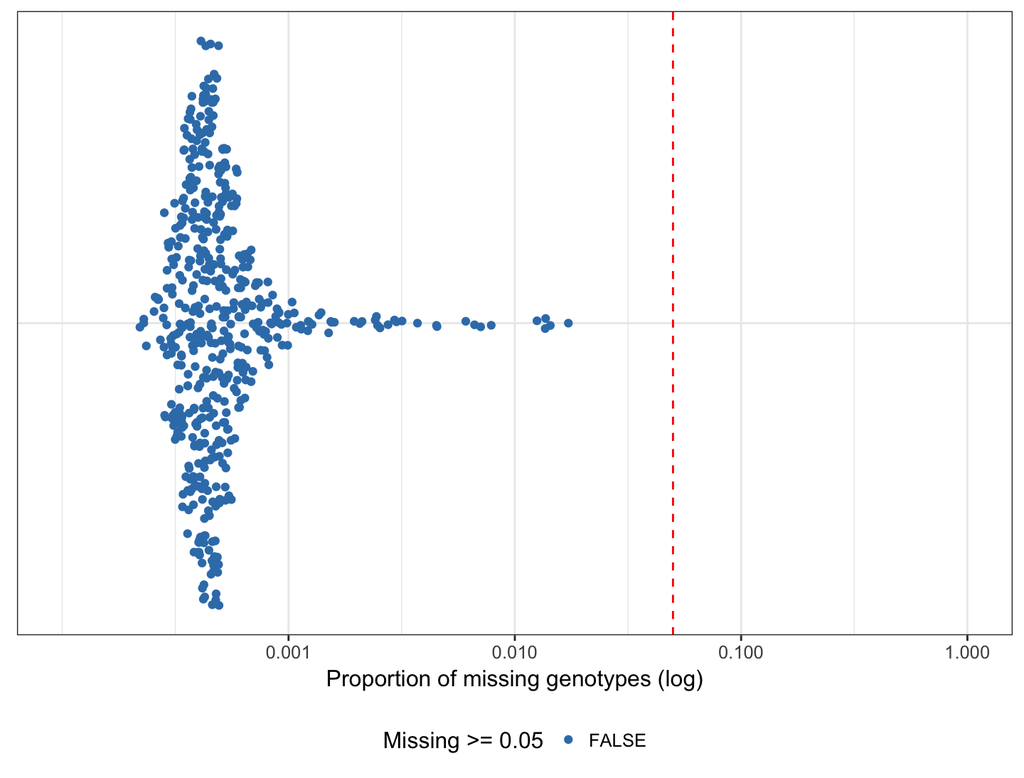

Fig. 3: Sample call rate distribution

*Table 1:* Samples with a call rate <= 95%

| FID | IID | N_MISS | N_GENO | F_MISS |
| --- | --- | --- | --- | --- |